# PA 8.1

Author

Kailyn Kragas

[View this project on GitHub](https://github.com/kailynnk/GSB-544.git)

# Palmer Penguins Modeling

Import the Palmer Penguins dataset and print out the first few rows.

Suppose we want to predict `bill_depth_mm` using the other variables in the dataset.

**Dummify** all variables that require this.

```python
! pip install palmerpenguins
```

```python
import pandas as pd
import numpy as np
from palmerpenguins import load_penguins
from sklearn.pipeline import Pipeline
from sklearn.compose import make_column_selector, ColumnTransformer
from sklearn.preprocessing import StandardScaler, OneHotEncoder, PolynomialFeatures
from sklearn.linear_model import LinearRegression
from sklearn.neighbors import KNeighborsRegressor
from sklearn.tree import DecisionTreeRegressor
from sklearn.model_selection import train_test_split, cross_val_score, GridSearchCV
from sklearn.metrics import r2_score, mean_squared_error
```

```python
penguins = load_penguins()
penguins = penguins.dropna()
penguins.head(5)
```

|  | species | island | bill_length_mm | bill_depth_mm | flipper_length_mm | body_mass_g | sex | year |
| --- | --- | --- | --- | --- | --- | --- | --- | --- |
| 0 | Adelie | Torgersen | 39.1 | 18.7 | 181.0 | 3750.0 | male | 2007 |
| 1 | Adelie | Torgersen | 39.5 | 17.4 | 186.0 | 3800.0 | female | 2007 |
| 2 | Adelie | Torgersen | 40.3 | 18.0 | 195.0 | 3250.0 | female | 2007 |
| 4 | Adelie | Torgersen | 36.7 | 19.3 | 193.0 | 3450.0 | female | 2007 |
| 5 | Adelie | Torgersen | 39.3 | 20.6 | 190.0 | 3650.0 | male | 2007 |

Let’s use the other variables to predict `bill_depth_mm`. Prepare your data and fit the following models on the entire dataset:

- Your best multiple linear regression model from before
- Two kNN models (for different values of K)
- A decision tree model

Create a plot like the right plot of Fig 1. in our `Model Validation` chapter with the training and test error plotted for each of your four models.

Which of your models was best?

```python
X = penguins.drop(columns = ["bill_depth_mm"])
y = penguins["bill_depth_mm"]

cat_cols = ['species', 'island', 'sex']
num_cols = ['remainder__bill_length_mm', 'remainder__flipper_length_mm', 'remainder__body_mass_g']

ct = ColumnTransformer([('dummify', OneHotEncoder(sparse_output=False, handle_unknown='ignore'), cat_cols)],
                         remainder='passthrough').set_output(transform="pandas")

ct_standardize = ColumnTransformer([('standardize', StandardScaler(), num_cols)],
                                   remainder='passthrough').set_output(transform="pandas")
```

## LRM

```python
lrm_pipeline = Pipeline([("preprocessing", ct),
                         ("standardize", ct_standardize),
                         ("linear_regression", LinearRegression())]).set_output(transform="pandas")
```

```python
lr_scores = cross_val_score(lrm_pipeline, X, y, cv = 5, scoring = 'neg_mean_squared_error')
lr_scores.mean()
```

```
np.float64(-0.8832156030162471)
```

## KNN

```python
knn_pipeline = Pipeline([("preprocessing", ct),
                         ("standardize", ct_standardize),
                         ("knn", KNeighborsRegressor())]).set_output(transform="pandas")
```

```python
param_grid = {'knn__n_neighbors': np.arange(1,8)}

gscv = GridSearchCV(knn_pipeline, param_grid=param_grid, cv = 5, scoring='neg_mean_squared_error')
gscv_dt_fitted = gscv.fit(X, y)
gscv_dt_results = pd.DataFrame(gscv_dt_fitted.cv_results_)
gscv_dt_results[['param_knn__n_neighbors', 'mean_test_score']].sort_values(by='mean_test_score', ascending=False)
```

|  | param_knn__n_neighbors | mean_test_score |
| --- | --- | --- |
| 3 | 4 | -1.075767 |
| 2 | 3 | -1.096364 |
| 5 | 6 | -1.101674 |
| 1 | 2 | -1.106818 |
| 6 | 7 | -1.127198 |
| 4 | 5 | -1.128981 |
| 0 | 1 | -1.160126 |

```python
knn_pipeline_n4 = Pipeline([("preprocessing", ct),
                         ("standardize", ct_standardize),
                         ("knn",  KNeighborsRegressor(n_neighbors=4))])

fitted_knn4 = knn_pipeline_n4.fit(X, y)
knn4_cv = cross_val_score(fitted_knn4, X, y, cv = 5, scoring = 'neg_mean_squared_error')
```

```python
knn_pipeline_n3 = Pipeline([("preprocessing", ct),
                         ("standardize", ct_standardize),
                         ("knn",  KNeighborsRegressor(n_neighbors=3))])

fitted_knn3 = knn_pipeline_n3.fit(X, y)
knn3_cv = cross_val_score(fitted_knn3, X, y, cv = 5, scoring = 'neg_mean_squared_error')
```

## Decision Tree

```python
dt_pipeline = Pipeline([("preprocessing", ct),
                        ("decision_trees", DecisionTreeRegressor())]).set_output(transform="pandas")
```

```python
max_depths = {'decision_trees__max_depth': np.array([2, 4, 6, 8, 10])}

gscv = GridSearchCV(dt_pipeline, param_grid=max_depths, cv = 5, scoring='neg_mean_squared_error')
gscv_dt_fitted = gscv.fit(X, y)
gscv_dt_results = pd.DataFrame(gscv_dt_fitted.cv_results_)
gscv_dt_results[['param_decision_trees__max_depth', 'mean_test_score']].sort_values(by='mean_test_score', ascending=False)
```

|  | param_decision_trees__max_depth | mean_test_score |
| --- | --- | --- |
| 0 | 2 | -0.759931 |
| 1 | 4 | -1.001563 |
| 2 | 6 | -1.352008 |
| 3 | 8 | -1.450258 |
| 4 | 10 | -1.562269 |

```python
dt_pipeline2 = Pipeline([("preprocessing", ct),
                         ("decision_trees", DecisionTreeRegressor(max_depth=2))])

fitted_dt = dt_pipeline2.fit(X, y)
```

```python
dt_cv = cross_val_score(fitted_dt, X, y, cv = 5, scoring = 'neg_mean_squared_error')
dt_cv
```

```
array([-1.06659575, -0.83587408, -0.74304059, -0.54671163, -0.60743478])
```

```python
dt_cv.mean()
```

```
np.float64(-0.7599313665778358)
```

### Results

Model with the smallest MSE is the decision tree with Max Depth = 2

**Create a plot like the right plot of Fig 1. in our `Model Validation` chapter with the training and test error plotted for each of your four models.**

```python
from plotnine import *
```

```python
X_train, X_test, y_train, y_test = train_test_split(X, y, test_size=0.30, random_state=0)

models = {"Linear Regression": LinearRegression(),
          "Decision Tree": DecisionTreeRegressor(max_depth=2),
          "kNN n=4": KNeighborsRegressor(n_neighbors=4),
          "kNN n=3": KNeighborsRegressor(n_neighbors=3)}

rows = []
for name, est in models.items():
  if name == "Decision Tree":
    pipe = Pipeline([("preprocessing", ct),
                     ("model", est)])
  else:
    pipe = Pipeline([("preprocessing", ct),
                     ("standardize", ct_standardize),
                     ("model", est)])

  pipe.fit(X_train, y_train)

  y_pred_tr = pipe.predict(X_train)
  y_pred_te = pipe.predict(X_test)

  rows.append({"Model": name, "type": "Train MSE",
               "MSE": mean_squared_error(y_train, y_pred_tr)})
  rows.append({"Model": name, "type": "Test MSE",
               "MSE": mean_squared_error(y_test, y_pred_te)})

df_error_long = pd.DataFrame(rows)

order = ["Linear Regression", "Decision Tree", "kNN n=4", "kNN n=3"]
df_error_long["Model"] = pd.Categorical(df_error_long["Model"], categories=order, ordered=True)
```

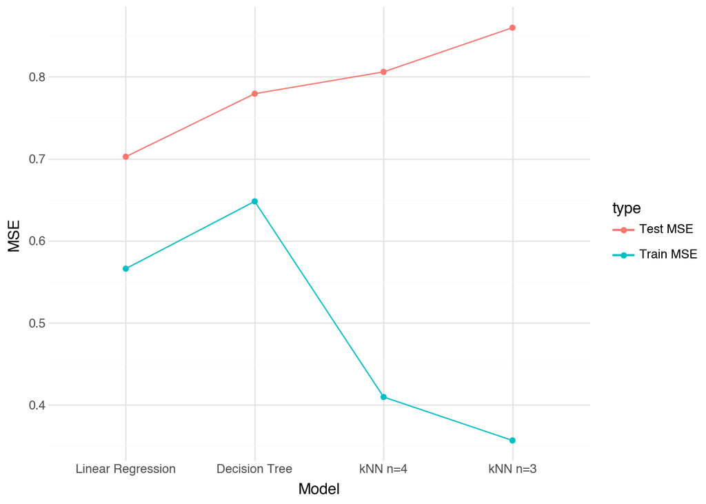

```python
(ggplot(df_error_long, aes(x = "Model", y = "MSE", color = "type", group = "type")) +
 geom_point() +
 geom_line() +
 labs(x = "Model", y = "MSE") +
 theme_minimal())
```